# The Rise of the Culturally Conservative Left in Latin America

Danissa Contreras-Guzmán

dzcontreras@utexas.edu

Ph.D. Candidate in Government | University of Texas at Austin

September 2, 2026

## The Rise of Cultural Issues in Latin America

- Increasing salience of cultural issues in elections (e.g., abortion, same-sex marriage, sexual education).
- Mobilization of culturally conservative and religious movements.
- Issue ownership by right-wing actors.
- But, some left-wing actors have embraced conservative and religious agendas.

[figure not shown]

**Figure 1**: Conservative Right-wing Politicians in LA.

[figure not shown]

**Figure 2**: Conservative Left-wing Politicians in LA.

**Why has the left adopted Cultural Conservatism in some Latin American countries, but not in others?**

## Defining the Culturally Conservative Left

- **Economic Dimension**: Poverty and inequality as major societal problems.
  - Policies that aim to reduce economic disparities.
- **Cultural Dimension**: Embrace of *cultural conservatism*.
  - Traditional visions of society → sexuality, gender, religiosity, bioethics, and morality.
    - Appeals to religious symbols, values, and ideas.
    - Support for culturally conservative policies.

## Theoretical Explanation

**Thesis**: The rise of the Culturally Conservative Left is the result of **strategic decisions** made by left-wing politicians who seek to attract an extensive base of support.

- **Electoral Incentives**: High levels of **cultural conservatism** among voters (Riker 1986; Chong and Druckman 2007).
- **Party constraints**: Leaders with **autonomy** from culturally progressive activists (May 1973; Aldrich 1983; Kitschelt 1994; Levitsky 2003; Miller & Schofield 2003).

## Theoretical Explanation

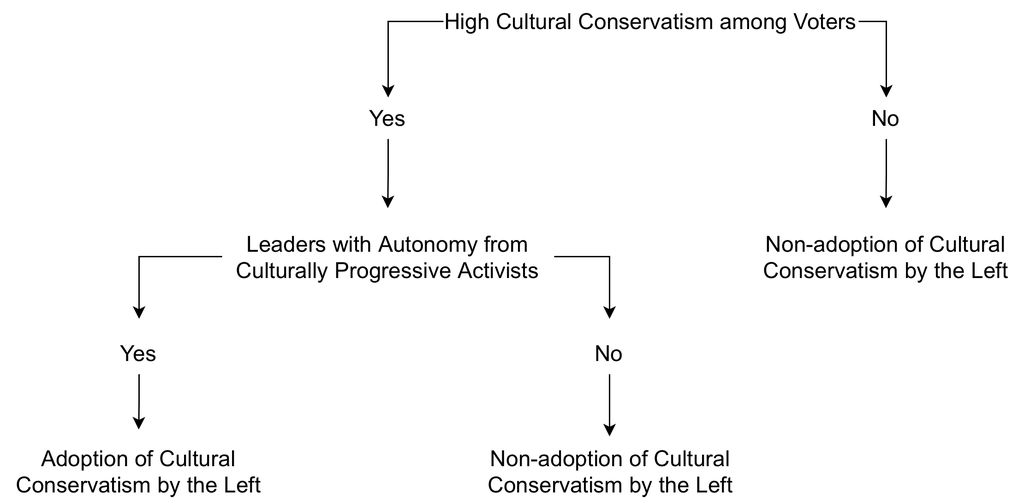

**Figure 3**: Causal Path for the Emergence of the Culturally Conservative Left.

## Hypotheses

- **Electoral Incentives**:
  - **H1**: Candidates who combine left-wing economic policies with culturally conservative positions attract an extensive base of voters.
- **Party Constraints**:
  - **H2a**: Party organizations that provide party leaders with autonomy from culturally progressive activists facilitate the adoption of Cultural Conservatism by the left.
  - **H2b**: Party organizations that constrain party leaders by empowering culturally progressive activists inhibit the adoption of Cultural Conservatism by the left.

**Electoral Incentives**

## Assessing Cultural Conservatism among LA Voters

Cultural preferences and religious behaviors in LA using data from the WVS and a Hierarchical IRT measurement model (Zhou, 2019).

- Homosexuality, abortion, divorce, euthanasia, religious attendance, and religious commitment.
- Divided by self-placement on the left-right scale.

## Trends in Cultural Conservatism

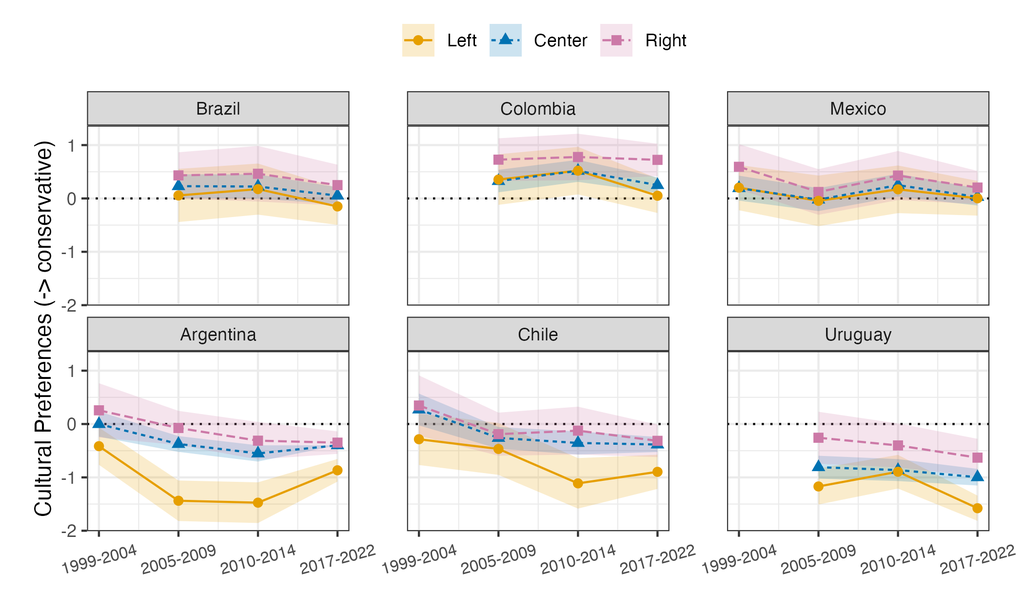

**Figure 4**: Evolution of Cultural Preferences by Ideological Self-Placement 1999-2022, World Values Survey, N = 23,573.

**From Personal Preferences to Voting Behavior**

## Testing the Effectiveness of the Culturally Conservative Left

A candidate choice conjoint experiment in Brazil and Mexico:

|  | Candidate A | Candidate B |
| --- | --- | --- |
| **Gender (2)** | Antonio | Valentina |
| **Party Affiliation (4B/3M)** | PRI | MORENA |
| **Economic Position (2)** | Cut anti-poverty programs but reduce taxes | Expand anti-poverty programs but raise taxes |
| **Cultural Position (2)** | Maintain current laws | Allow abortion up to 16 weeks |

Note: In parentheses, the number of attribute levels.

**Table 1**: Example Profiles for the Conjoint Experiment.

## Results Experiment: Mexico and Brazil

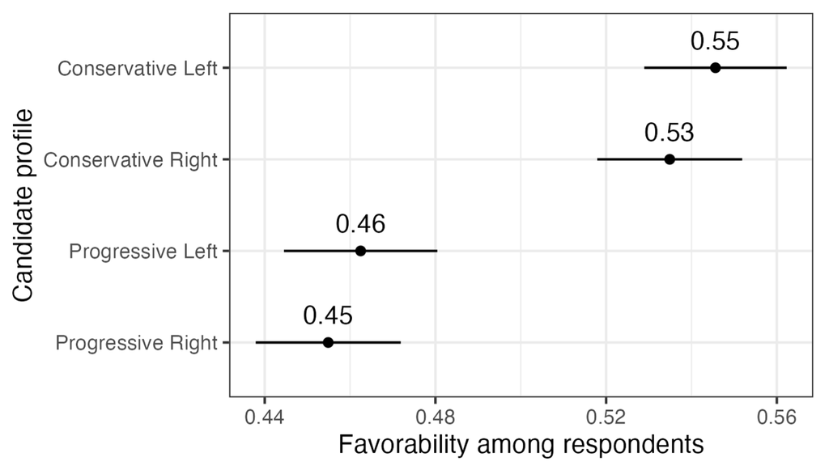

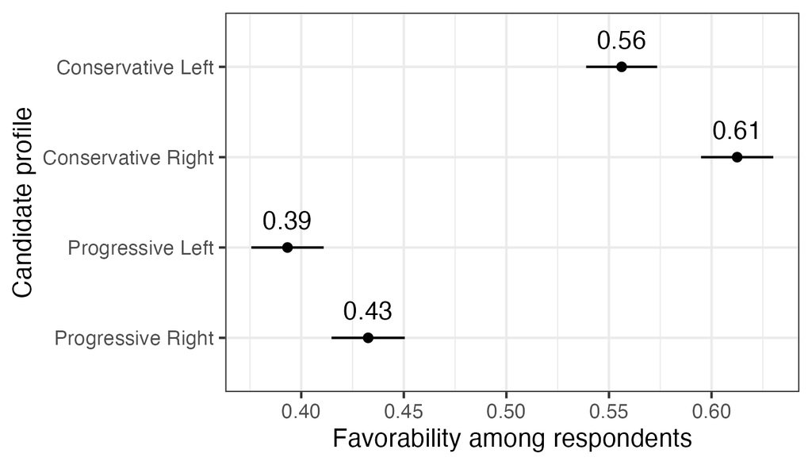

**Party Constraints**

## Case Studies: MORENA and the PT

Two cases with high cultural conservatism, but different outcomes: **MORENA** and the **PT**

- Similar patterns:
  - Left-wing parties with charismatic leaders.
  - Broad coalitions.
  - Challenges from the right, and from the left.
- But,
  - MORENA: Secularism in Mexico.
  - PT: previous bonds with the religious world.
- Pieces of evidence:
  - More than 150 interviews with key actors.
  - Analysis of party documents.
  - News Coverage.

## Autonomous Leadership and the Rise of the CCL: MORENA

**Moving Party Platforms…**

- MORENA started as a progressive party.
  - Inclusion of feminist and LGBTQ+ activists and agendas.
- However, things stated to change in 2017.
  - Alliances with religious and conservative forces.
  - Increasing appeals to religiosity.
  - Ambiguous support for culturally progressive policies.
- Movements toward the conservative side triggered protests in the party.
  - Progressive activist rejected the alliances with conservative groups → a threat to their agendas.

[figure not shown]

**Figure 6**: AMLO showing a holy card during the pandemic.

## Autonomous Leadership and the Rise of the CCL: MORENA

**Incentives: High Cultural Conservatism**

- Leaders justified the alliance for electoral reasons:
  - “The party should look like society.”
  - Better performance among religious voters.
  - Reduce the “threat” of the left.

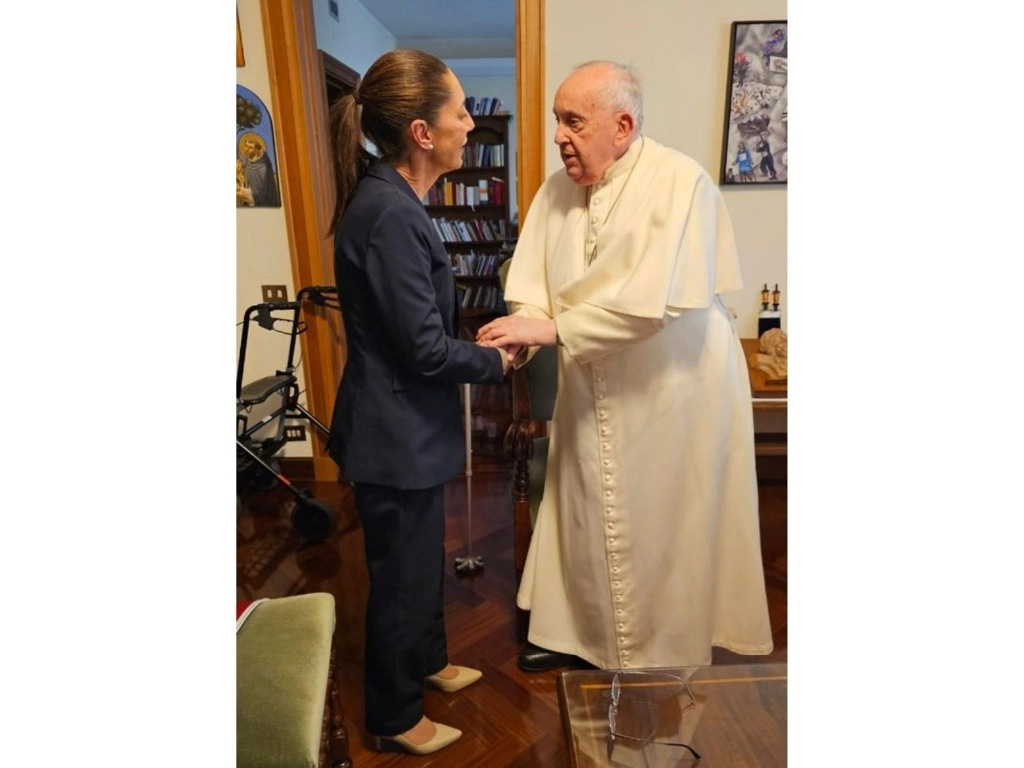

**Figure 7**: Meeting between Claudia Sheinbaum and the Pope, 2024.

“When MORENA started, **it gave space to very conservative parties such as the PES**. And then there were many people who, once in office, did not vote as they should have. Because **they were against all the party’s progressive agenda**.”

MORENA LGBTQ+ Activist, Aug. 2024.

“[Activists] don’t carry any weight; **they have no influence at all**. Because the model is built that way.”

MORENA Political Strategist, Aug. 2025.

## Autonomous Leadership and the Rise of the CCL: MORENA

**Lack of Constraints: Autonomy of leaders**

- A movement-party?
- MORENA’s populist organization concentrate power in the leader(s):
  - Nominations.
  - Budget.
- Culturally progressive activists lack tools to constraint leaders’ decisions.

[figure not shown]

**Figure 8**: MORENA rejecting abortion in Puebla, 2024.

## Autonomous Leadership and the Rise of the CCL: MORENA

- However, *a different way of embracing cultural conservatism*.
  - Some space for the development of culturally progressive agendas.
  - The abortion case.
  - Maintaining diverse bases of support.

[figure not shown]

**Figure 9**: MORENA supporting Abortion in Puebla, 2024.

## Constrained Leadership and Failed Adaptation: PT

**Understanding Incentives**

- High electoral pressure to modify the PT’s cultural platform:
  - Increasing rejection among religious voters, especially evangelical ones.
  - Increasing salience of cultural issues.
  - Issue ownership by right-wing actors.

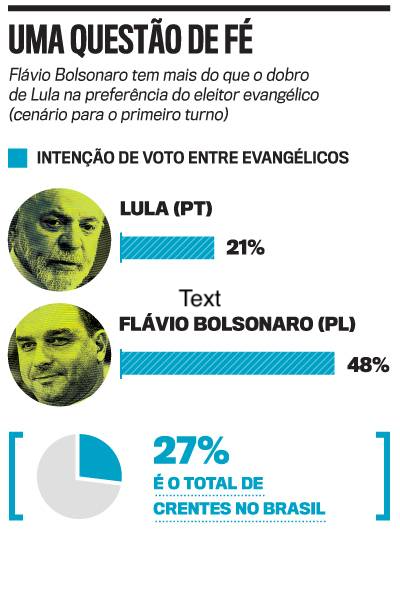

**Figure 10**: Datafolha Survey, 2024.

## Constrained Leadership and Failed Adaptation: PT

**Modifying Party Platform?**

- Attempts from party leaders:
  - Courses to prepare candidates to “speak with” evangelical and catholic voters.
  - Put evangelical members in positions of power.
  - Letter for Catholic and evangelical communities.
  - A PT evangelical church?
- Also attempts from some party members:
  - Creation of the *Núcleo Evangélico*.
- Failed attempts…

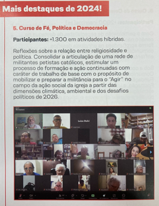

**Figure 11**: PT’s Course of Faith, Politics, and Democracy

“Internally, there is a prejudice among some who believe that all evangelicals are far-right… **We consider the leadership to be the most open to these social issues [inclusion of religious elements], but we face very conventional party members**, who consider, as I said, this religious issue to be secondary within the party.”

Member of the *Núcleo Evangélico*, Aug. 2025.

“It’s also obvious that by forming this alliance between us and the churches, **they will try to impose cuts on our program.** They will attempt to limit our program.”

Feminist activist, Jul. 2025.

“So, **we began supporting these key leaders and putting them on our side**, ensuring they could be elected. Then we started with a budget of 3% of the PT.”

LGBTQ+ Activist, Dec. 2024.

## Constrained Leadership and Failed Adaptation: PT

**Constraints: Limited Automony of Leaders**

- Party organization that empowers culturally progressive activists:
  - Offices that provide voice and (sometimes) vote in the party decisions and strategies.
  - Specific budget for preparing and supporting candidates.
  - Avoid adaptation to maintain agendas. Electoral costs?

## Conclusion

- Electoral incentives for party adaptation are necessary, but insufficient to trigger changes in party platforms.
- More leadership autonomy → more capacity of adaptation.
  - More democratic structure can constrain adaptation.
- Implications:
  - Increasing salience of cultural issues.
  - The effect of the CCL on the party system.
  - Stability of party brands.

## Thank You

**Danissa Contreras-Guzmán**  
dzcontreras@utexas.edu  
https://dzcontreras.github.io

## Appendix

## Results Experiment: Brazil

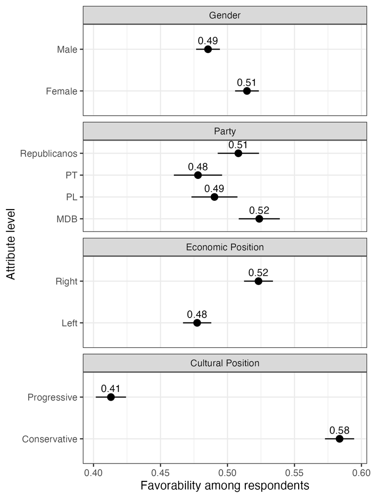

**Figure A1**: Marginal Means by Conjoint Attributes (Brazil), with 95% Confidence Intervals (N=1293).

## Results Experiment: Mexico

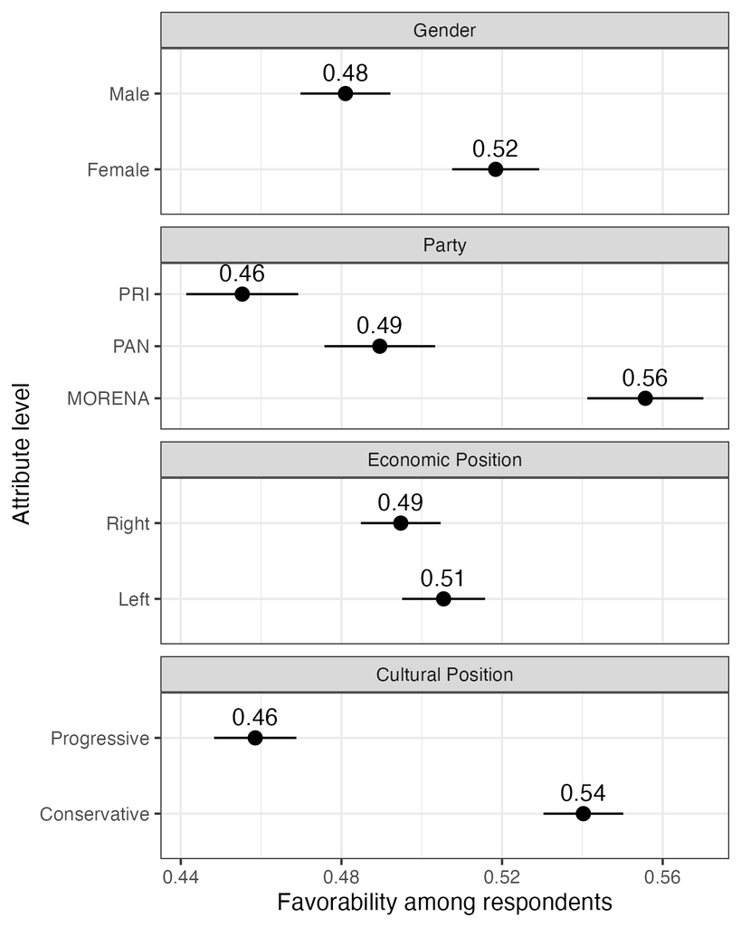

## Results Experiment: Brazil (subgroup)

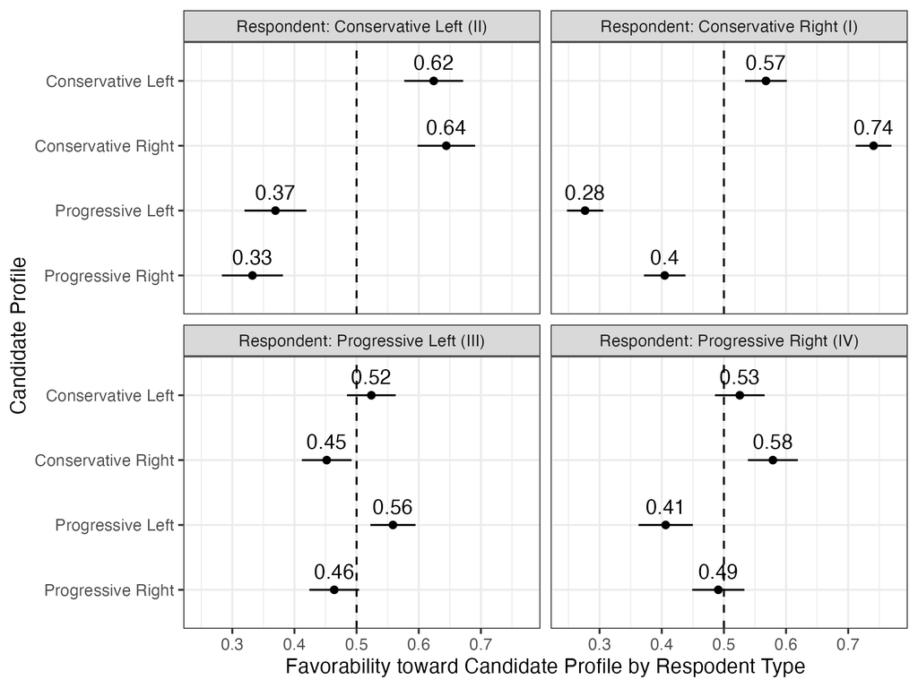

**Figure A3**: Marginal Means by Candidate Profile per Type of Respondents in Brazil, with 95% CI (N=1,293).

## Results Experiment: Mexico (subgroup)

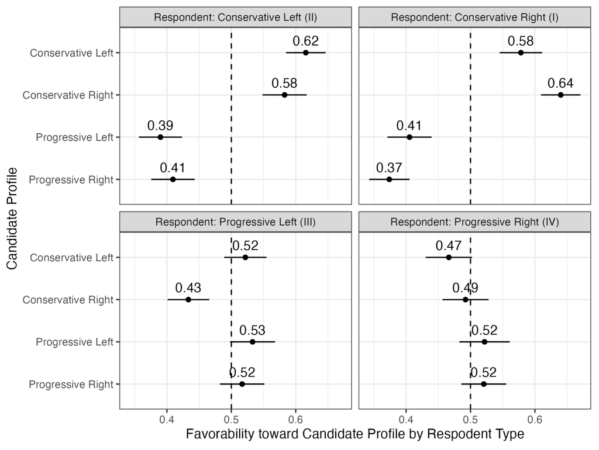

**Figure A4**: Marginal Means by Candidate Profile per Type of Respondents in Mexico, with 95% CI (N=2,738).